# Homework 3 Answers

BSTA 550

Modified

October 22, 2026

Below are some select answers from the homework.

## Questions

### 1. Mystery constant

Suppose $X$ is a discrete random variable with probability mass function (pmf) $p_X(x) = c(4- x)$ for $x$ in $\{-1, 2, 3\}$ and $p_X(x) = 0$ otherwise.

#### Part a

What is the value of $c$ that makes $p_X(x)$ a valid pmf?

$c = \dfrac{1}{8}$

#### Part b

Write the piecewise pmf of $X$ and make a plot of it. (You can draw the plot by hand or make it in R.)

Not given

#### Part c

What is the cumulative distribution function (CDF) of $X$? Write the piecewise CDF.

$$F_X(x) = \begin{cases} 0 & x < -1 \\ \frac{5}{8} & -1 \leq x < 2 \\ \frac{7}{8} & 2 \leq x < 3 \\ 1 & x \geq 3 \end{cases}$$

#### Part d

Make a plot of the CDF. (You can draw the plot by hand or make it in R.)

Not given

### 2. Wastebasket basketball

Chris tries to throw a ball of paper in the wastebasket behind his back (without looking). He estimates that his chance of success each time, regardless of the outcome of the other attempts, is $1/3$. Let $X$ be the number of attempts required. If he is not successful within the first 5 attempts, then he quits, and he lets $X = 6$ in such a case.

#### Part a

Write the piecewise pmf of $X$ and make a plot of it. (You can draw the plot by hand or make it in R.)

$$p_X(x) = \begin{cases} \left(\frac{2}{3}\right)^{x-1}\left(\frac{1}{3}\right) & x = 1, 2, 3, 4, 5 \\ \left(\frac{2}{3}\right)^{5} & x = 6 \\ 0 & \text{otherwise} \end{cases}$$

#### Part b

Write the piecewise CDF of $X$ and make a plot of it. (You can draw the plot by hand or make it in R.)

Not given

#### Part c

Simulate 10,000 trials of this experiment in R. Use your simulation to plot the approximate pmf of $X$ and to check your answers to Parts a and b.

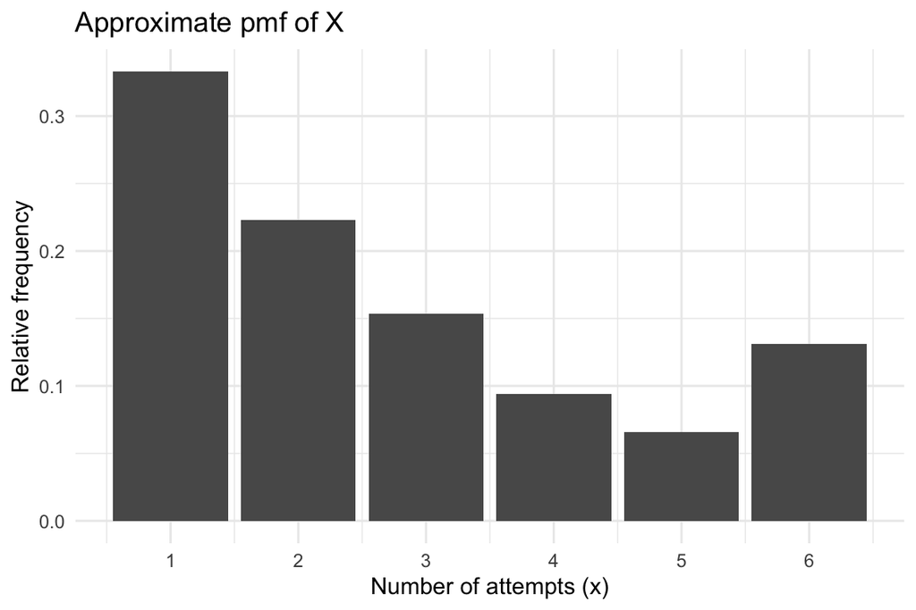

| x | Approximate pmf | Approximate CDF |
| --- | --- | --- |
| 1 | 0.333 | 0.333 |
| 2 | 0.223 | 0.556 |
| 3 | 0.154 | 0.709 |
| 4 | 0.094 | 0.803 |
| 5 | 0.066 | 0.869 |
| 6 | 0.131 | 1.000 |

Answers will vary slightly, but should be close to the exact pmf and CDF from Parts a and b.

### 3. Sore arm after a flu shot

Suppose 20% of adults have a sore arm the day after getting a flu shot. A pharmacy gives flu shots to $n = 10$ adults one morning. Assume that whether one adult gets a sore arm is independent of the other adults. Let $X$ be the number of these 10 adults who have a sore arm the next day.

#### Part a

Explain why $X$ is a binomial random variable. What are the parameters $n$ and $p$?

$X \sim \text{Binom}(n = 10, p = 0.2)$

#### Part b

Write the pmf of $X$. Then use it to calculate $\mathbb{P}(X = 3)$ by hand.

Not given

#### Part c

Use `dbinom()` in R to calculate $\mathbb{P}(X = x)$ for every possible value of $X$, and make a bar plot of the pmf. (You can draw the plot by hand or make it in R.) Does your answer from Part b match?

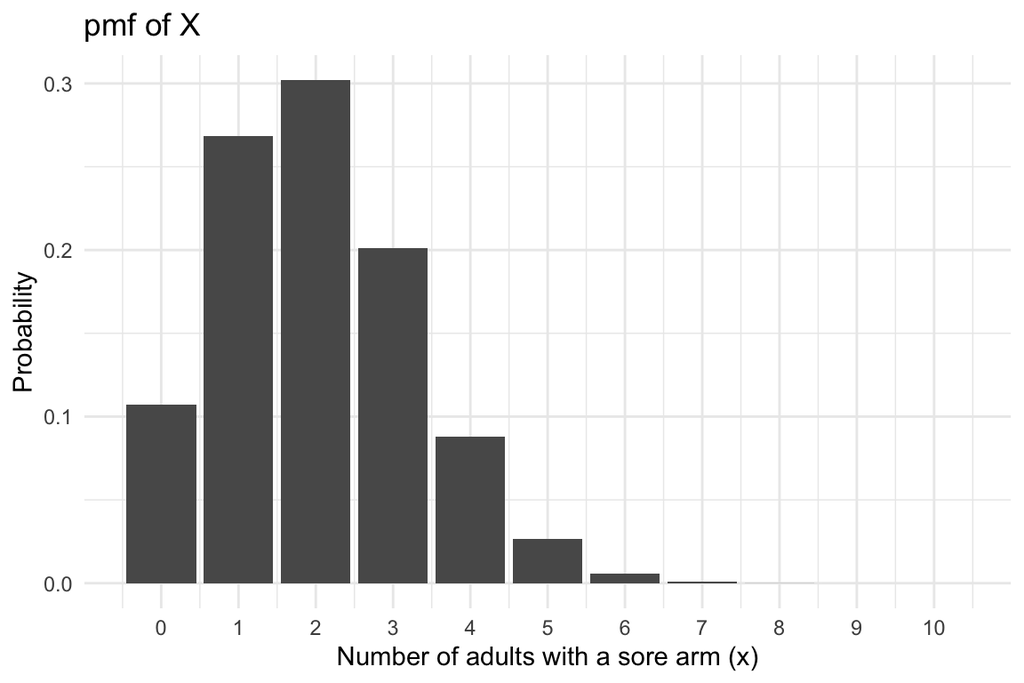

`dbinom()` should match your answer in Part b.

#### Part d

Find $\mathbb{P}(X \leq 2)$ two ways: by hand using the pmf, and with `pbinom()` in R.

Not given

#### Part e

Simulate 10,000 mornings at the pharmacy (each with 10 adults) to check your answers to Parts b and d.

- With `sample()`: $\mathbb{P}(X = 3) \approx$ 0.198 and $\mathbb{P}(X \leq 2) \approx$ 0.681
- With `rbinom()`: $\mathbb{P}(X = 3) \approx$ 0.194 and $\mathbb{P}(X \leq 2) \approx$ 0.688

Answers will vary slightly, but should be close to your answers in Parts b and d.

### 4. Lab processing time

A lab processes blood samples. Suppose the processing time $X$ (in minutes) for a sample is equally likely to be anywhere between 20 and 50 minutes. So $X$ has pdf $f_X(x) = c$ for $20 \leq x \leq 50$, and $f_X(x) = 0$ otherwise.

#### Part a

What is the value of $c$ that makes $f_X(x)$ a valid pdf?

$c = \dfrac{1}{30}$

#### Part b

Find $\mathbb{P}(30 \leq X \leq 40)$.

Not given

#### Part c

Find $\mathbb{P}(X > 45)$.

$\mathbb{P}(X > 45) = \dfrac{1}{6} \approx 0.167$

#### Part d

Find $\mathbb{P}(X = 35)$.

Not given

#### Part e

Simulate 10,000 processing times in R with `runif()` and use them to check your answers to Parts b–d.

- $\mathbb{P}(30 \leq X \leq 40) \approx$ 0.333
- $\mathbb{P}(X > 45) \approx$ 0.169
- $\mathbb{P}(X = 35) \approx$ 0 (no simulated value is exactly 35)

Answers will vary slightly, but should be close to your answers in Parts b–d.

### 5. A continuous mystery constant

Consider the following pdf:
$$f_X(x) = \begin{cases} kx^9(1-x)^2 & \text{if } 0 \leq x \leq 1 \\ 0 & \text{otherwise} \end{cases}$$

#### Part a

What is the constant $k$ that makes $f_X(x)$ a valid pdf?

$k=660$

#### Part b

What is the CDF $F_X(x)$?

Not given

### 6. From a CDF to a pdf

Let $X$ be a random variable with CDF
$$F_X(x)= \begin{cases} 0 & \text{if } x < 0 \\ \dfrac{x^2}{4} & \text{if } 0 \leq x \leq 2 \\ 1 & \text{if } x > 2 \end{cases}$$

#### Part a

Find the pdf $f_X(x)$.

$$f_X(x) = \begin{cases} \dfrac{x}{2} & \text{if } 0 \leq x \leq 2 \\ 0 & \text{otherwise} \end{cases}$$

#### Part b

Use the CDF to find $\mathbb{P}(0.5 \leq X \leq 1.5)$.

Not given

#### Part c

Find the median of the distribution of $X$.

Median $= \sqrt{2} \approx 1.414$

#### Part d

Simulate 10,000 values of $X$ with the inverse CDF method from Lesson 9, and use them to check your answers to Parts b and c.

Not given